# L’essentiel du DCIEM

(version DCIEM 1983)

Pascal Monestiez  
Juin 2026  
Version support de cours MF1 et GP-N4

## Origine du DCIEM - il y a plus d’un demi siècle

- **DCIEM n’est pas à l’origine le nom d’un modèle**, mais celui de l’institut où il a été conçu : **Defence and Civil Institute of Environmental Medicine**, Downsview, Ontario, Canada
- **Nombreux travaux sur les modèles de décompression dans les années 60–80** pour améliorer les tables (Workman 1965, Bühlmann 1969, Hennessy and Hempleman 1977, Yount and Hoffman -VPM- 1986, Wienke RGBM 1990). **Le DCIEM naît à cette période**
- **Apparition des décompressimètres « analogiques »** (pneumatic decompression computer) dans les 70’s et modélisation physique de ces « décompressimètres » **(Hills B.A. 1967)** par équations de diffusion

[figure not shown]

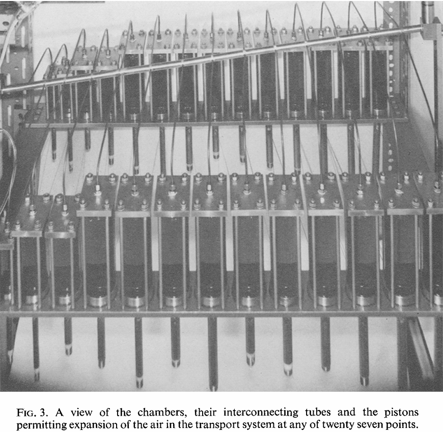

Pascal Monestiez, Juin 2026, CC BY NC

## Origine du DCIEM - les premières versions

- A partir des travaux (et des équations) de Hills, **Kidd et Stubbs (1969)** proposent un premier modèle (appelé KS-1971) qui remet en cause le modèle exponentiel de Haldane (perfusion - symétrie de la saturation et de la désaturation).
- Le but était d’être **aussi conservatif que les tables** de l’époque (Royal Navy, US Navy). Le KS-1971 semble trop conservatif pour les plongées courtes peu engagées et pour les plongées très longues et engagées
- Le KS-1971 est modifié en conséquence par Nishi et Lauckner (1984) qui proposent **le DCIEM 1983 model** (introduction de droites de M-values).  
  Il donnera les tables **DCIEM Diving Manual** (1986).

**Kidd D.J. and Stubbs R.A. (1969)** The use of the pneumatic analog computer for divers, in P.B. Bennett and D.H. Elliott, Eds., The Physiology and Medicine of Diving and Compressed Air Work, 1st ed., pp. 386-413, Bailliere, Tindall and Cassell, London. 1969.

**Nishi R. Y. and Lauckner G.R. (1984)** Development of the DCIEM 1983 decompression model for compressed air diving.  
DCIEM No. 84-R-44, Defence and Civil Institute of Environmental Medicine, Downsview, Ontario, pp. 54.

Pascal Monestiez, Juin 2026, CC BY NC

## Modèle de saturation/désaturation en série

- **Un modèle extrêmement simple à 4 équations et 2 coefficients** :

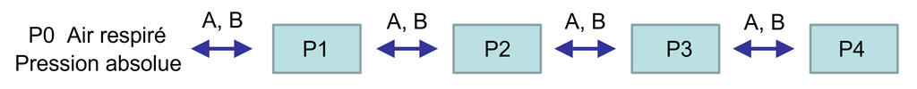

- Pour chaque compartiment, la **variation des** *“pressions”* **Pi** (c-à-d. les *tensions*  
  en air et non en gaz inerte) **est la différence entre ce qui rentre et ce qui sort**

**dP1/dt = A ( ( B + P0 + P1) ( P0 - P1 ) - ( B + P1 + P2 ) ( P1 - P2 ) )**

**dP2/dt = A ( ( B + P1 + P2 ) ( P1 - P2) - ( B + P2 + P3 ) ( P2 - P3 ) )**

**dP3/dt = A ( ( B + P2 + P3 ) ( P2 - P3 ) - ( B + P3 + P4 ) ( P3 – P4) )**

**dP4/dt = A ( B + P3 + P4 ) ( P3 – P4 )**

- Toutes les valeurs Pi sont exprimées en Pabs (unité msw = mètre eau de mer).  
  Les coefficients A et B sont les mêmes pour les 4 compartiments :  
  A = 0,0002596 et B = 83,67 (constantes de flux pour l’air, pas de temps dt=1mn)

Pascal Monestiez, Juin 2026, CC BY NC

## Les astuces qui simplifient les calculs (optionel)

- **Les pressions sont mesurées en msw (mètres d’eau de mer)**  
  La pression hydrostatique correspond donc à la profondeur  
  La pression absolue est la profondeur + 10,06 msw (Patm ou Psl)
- **La gestion des gaz dissous dans les compartiments**  
  Les tensions modélisées ne sont PAS exprimées en pression partielle  
  du gaz neutre (N<sub>2</sub>) mais en pression absolue du compartiment  
  (cela évite d’avoir à multiplier ou diviser par 0.8 pour gérer les TN<sub>2</sub>)
- **En remontant, le respect des sursaturations critiques** donnent des pressions limites par compartiment, qui sont donc **directement les profondeurs plafonds** si on soustrait la Patm (ou Psl ou P at sea level).

Déconcertant mais efficace

Pascal Monestiez, Juin 2026, CC BY NC

## Détermination des Paliers ou SAD (Safe Ascent Depths)

- **Dans la version DCIEM 1983 :**  
  une formule du type Droite de M-values pour les compartiments 1 et 2 seulement (soit deux coefficients chacun, l’équivalent des *a* et *b* de Bühlmann)

  **SAD = Pi / R - Offset - Patm**

  avec **R = 1,3 et Offset = 4,8** pour le premier compartiment  
  et **R = 1,385 et Offset = 2.5** pour le second compartiment
- Le SAD est directement la **profondeur plafond** exprimée en “msw” (mètres d’eau de mer)
- Il est facile d’en déduire la **profondeur du palier** : multiple de 3m juste un peu plus profond
- Les **vitesses de descente ET de remontée** sont de**18m/mn**  
  (devenues **15m/mn** dans la version la plus récente)

Pascal Monestiez, Juin 2026, CC BY NC

## Les trois points qui caractérisent le DCIEM

- **Le nombre de compartiments et leur disposition**  
  4 compartiments disposés en série

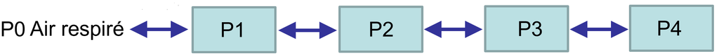

  (Pas Haldanien)
- **Les équations qui régissent les transferts entre compartiments**  
  L’équation du flux élémentaire est non linéaire. Elle est l’approximation d’un **modèle de diffusion** (2<sup>nde</sup> loi de Fick) et la solution n’est plus une exponentielle.  
  Il y a **dissymétrie entre charge et décharge** (Pas Haldanien)
- **Les limites SAD (Safe Ascent Depth)**  
  Modèle type droite de M-values pour le DCIEM 83  
  **SAD = P / R - Off - Patm** (Tout à fait Haldanien)

Pascal Monestiez, Juin 2026, CC BY NC

## Exemple de simulations du DCIEM

**Animations avec charges et décharges ainsi que les flux**

Liens ci-dessous

- [Simulation DCIEM 39m 25mn](https://pmonestiez.github.io/dciem/anim3)  
  Paliers : 9m 3mn - 6m 7mn - 3m 11mn DTR=23mn  
  (ajouter les 2mn de remontée aux 9m pour retrouver les Tables DCIEM publiées)
- [Simulation DCIEM 30m 50mn](https://pmonestiez.github.io/dciem/anim2)  
  Paliers: 9m 2mn - 6m 9mn - 3m 28mn DTR=41mn

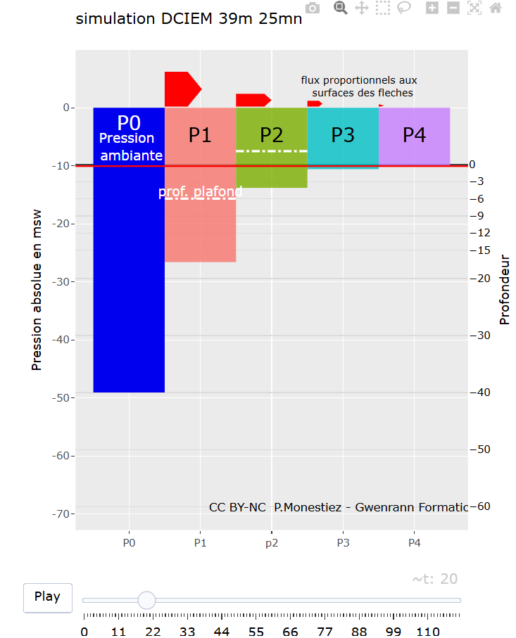

Pascal Monestiez, Juin 2026, CC BY NC

## Zoom sur l’équation de base du modèle (optionel)

- **Flux de P1 vers P2 = A ( B + P1 + P2) ( P1 – P2 )**
- **Equation non-linéaire** dépendant du gradiant **ET** des pressions absolues
- **Une résolution numérique est nécessaire**. La solution n’est plus l’exponentielle; la charge et la décharge ne sont plus symétriques. Une approximation de la période T<sub>1/2</sub> est exprimable à partir de Pi (initiale) et Pf (finale)

**La pseudo-période T<sub>1/2</sub> dépend de Pi et Pf**

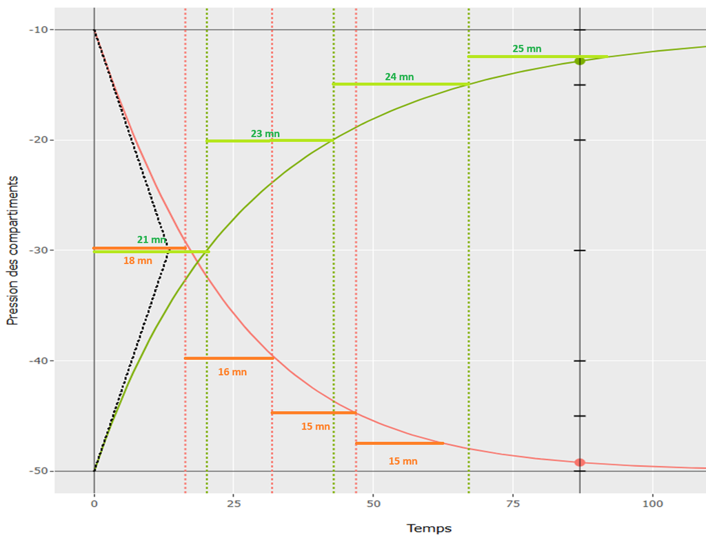

Pascal Monestiez, Juin 2026, CC BY NC

## Et les successives alors ?

- Le DCIEM **n’utilise pas de procédure type « majoration »** calculée sur les compartiments lents (MN90 T=120mn, Tables Buhlmann 1987 T=77mn)
- **Il calcule vraiment les successives à partir de son modèle** : les compartiments P3 et P4 continuent à se charger bien après le retour en surface et sont encore chargés au début de la seconde plongée
- [**Exemple de simulation de plongées successives**](https://pmonestiez.github.io/dciem/anim21) avec le DCIEM
- Le DCIEM donne des procédures de décompression similaires à celles des tables avec majorations (mais fait le calcul ce qui permet d’autres profils que les plongées carrées)
- Le DCIEM a été validé expérimentalement pour des successives  
  variées et engagées. Il représente donc une solution très fiable

Pascal Monestiez, Juin 2026, CC BY NC

## En guise de synthèse

- **Simplicité** : Le DCIEM a seulement 6 parametres (3 pour le KS-1971). En comparaison, le ZHL-16C a presque 50 paramètres : [T,a,b]x16 + GF
- **Efficacité** : Le DCIEM couvre un large spectre de situations dont les successives multiples. Il apparait comme plutôt sûr car légèrement plus conservatif que la majorité des autres modèles et a une fiabilité semblable aux tables (comportement non documenté face aux yoyos)
- **Robustesse** : Il est utilisé depuis les années 80 dans le monde militaire et professionnel. Il n’a quasiment pas été modifié depuis son origine.
- Sa simplicité et son efficience en terme de paramétrage lui confère **sur le plan mathématique** une **certaine élégance** en comparaison de tous les autres modèles

Pascal Monestiez, Juin 2026, CC BY NC

## Remerciements

Remerciements à Jean-Pierre Montseny et Alain Foret pour toutes les informations et documents qu’ils m’ont transmis, et pour tous les échanges enrichissants suscités

Les simulations du modèle et la résolution des équations différentielles ont été codées sous le logiciel R. Les graphiques et animations ont été réalisés avec les packages ggplot2 et ggplotly, et la présentation avec les environnements Quarto, Markdown et Revealjs

Cette présentation, d’autres supports et les animations sont accessibles sous :  
**https://pmonestiez.github.io/dciem/**

Pascal Monestiez, Juin 2026, CC BY NC